# Homework day 3 week 10

```r
library(tidyverse)
```

- 1 MVP

*** 1. Load the diamonds.csv data set and undertake an initial exploration of the data.

```r
diamonds <- read_csv("data/diamonds.csv")
```

```r
summary(diamonds)
```

```
       X1            carat            cut               color             clarity
 Min.   :    1   Min.   :0.2000   Length:53940       Length:53940       Length:53940
 1st Qu.:13486   1st Qu.:0.4000   Class :character   Class :character   Class :character
 Median :26970   Median :0.7000   Mode  :character   Mode  :character   Mode  :character
 Mean   :26970   Mean   :0.7979
 3rd Qu.:40455   3rd Qu.:1.0400
 Max.   :53940   Max.   :5.0100
     depth           table           price             x                y
 Min.   :43.00   Min.   :43.00   Min.   :  326   Min.   : 0.000   Min.   : 0.000
 1st Qu.:61.00   1st Qu.:56.00   1st Qu.:  950   1st Qu.: 4.710   1st Qu.: 4.720
 Median :61.80   Median :57.00   Median : 2401   Median : 5.700   Median : 5.710
 Mean   :61.75   Mean   :57.46   Mean   : 3933   Mean   : 5.731   Mean   : 5.735
 3rd Qu.:62.50   3rd Qu.:59.00   3rd Qu.: 5324   3rd Qu.: 6.540   3rd Qu.: 6.540
 Max.   :79.00   Max.   :95.00   Max.   :18823   Max.   :10.740   Max.   :58.900
       z
 Min.   : 0.000
 1st Qu.: 2.910
 Median : 3.530
 Mean   : 3.539
 3rd Qu.: 4.040
 Max.   :31.800
```

```r
diamonds
```

| X1 | carat | cut | color | clarity | depth | table | price | x | y | z |
| --- | --- | --- | --- | --- | --- | --- | --- | --- | --- | --- |
| 1 | 0.23 | Ideal | E | SI2 | 61.5 | 55.0 | 326 | 3.95 | 3.98 | 2.43 |
| 2 | 0.21 | Premium | E | SI1 | 59.8 | 61.0 | 326 | 3.89 | 3.84 | 2.31 |
| 3 | 0.23 | Good | E | VS1 | 56.9 | 65.0 | 327 | 4.05 | 4.07 | 2.31 |
| 4 | 0.29 | Premium | I | VS2 | 62.4 | 58.0 | 334 | 4.20 | 4.23 | 2.63 |
| 5 | 0.31 | Good | J | SI2 | 63.3 | 58.0 | 335 | 4.34 | 4.35 | 2.75 |
| 6 | 0.24 | Very Good | J | VVS2 | 62.8 | 57.0 | 336 | 3.94 | 3.96 | 2.48 |
| 7 | 0.24 | Very Good | I | VVS1 | 62.3 | 57.0 | 336 | 3.95 | 3.98 | 2.47 |
| 8 | 0.26 | Very Good | H | SI1 | 61.9 | 55.0 | 337 | 4.07 | 4.11 | 2.53 |
| 9 | 0.22 | Fair | E | VS2 | 65.1 | 61.0 | 337 | 3.87 | 3.78 | 2.49 |
| 10 | 0.23 | Very Good | H | VS1 | 59.4 | 61.0 | 338 | 4.00 | 4.05 | 2.39 |

[output cut: 990 more lines]

*** 2. We expect the carat of the diamonds to be strong correlated with the physical dimensions x, y and z. Use ggpairs() to investigate correlations between these four variables.

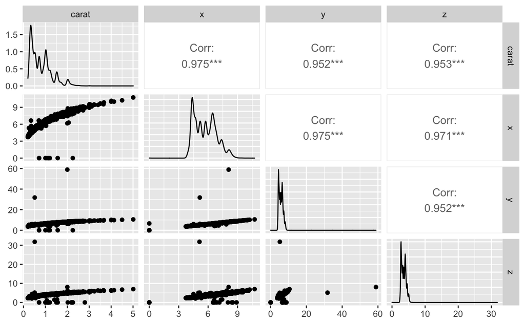

```r
library(GGally)

carat_xyz <- diamonds %>%
  select(carat, x, y, z)

ggpairs(carat_xyz)
```

all corr above 0.9 so very high correlations

*** 3. So, we do find significant correlations. Let’s drop columns x, y and z from the dataset, in preparation to use only carat going forward.

```r
diamonds_no_xyz <- diamonds %>%
  select(-c(x, y, z))
diamonds_no_xyz
```

| X1 | carat | cut | color | clarity | depth | table | price |
| --- | --- | --- | --- | --- | --- | --- | --- |
| 1 | 0.23 | Ideal | E | SI2 | 61.5 | 55.0 | 326 |
| 2 | 0.21 | Premium | E | SI1 | 59.8 | 61.0 | 326 |
| 3 | 0.23 | Good | E | VS1 | 56.9 | 65.0 | 327 |
| 4 | 0.29 | Premium | I | VS2 | 62.4 | 58.0 | 334 |
| 5 | 0.31 | Good | J | SI2 | 63.3 | 58.0 | 335 |
| 6 | 0.24 | Very Good | J | VVS2 | 62.8 | 57.0 | 336 |
| 7 | 0.24 | Very Good | I | VVS1 | 62.3 | 57.0 | 336 |
| 8 | 0.26 | Very Good | H | SI1 | 61.9 | 55.0 | 337 |
| 9 | 0.22 | Fair | E | VS2 | 65.1 | 61.0 | 337 |
| 10 | 0.23 | Very Good | H | VS1 | 59.4 | 61.0 | 338 |

[output cut: 990 more lines]

*** 4. We are interested in developing a regression model for the price of a diamond in terms of the possible predictor variables in the dataset.

*** i. Use ggpairs() to investigate correlations between price and the predictors (this may take a while to run, don’t worry, make coffee or something).

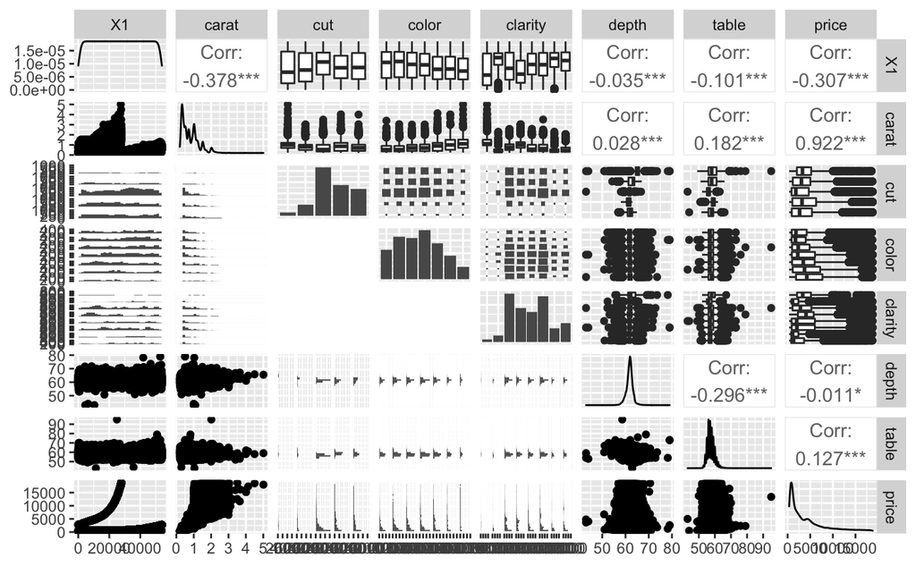

```r
ggpairs(diamonds_no_xyz)
```

*** ii. Perform further ggplot visualisations of any significant correlations you find.

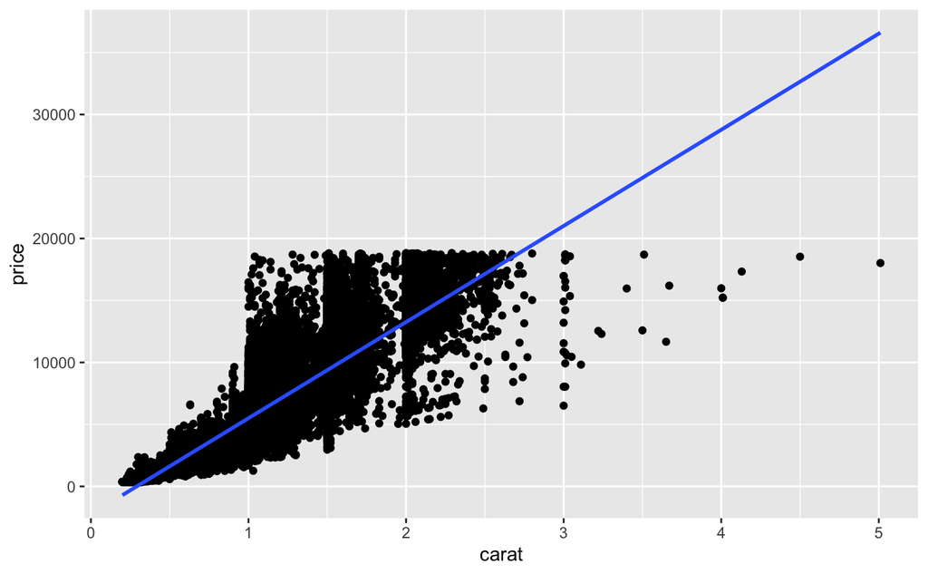

```r
diamonds_no_xyz %>%
  ggplot(aes(x = carat, y = price)) +
  geom_point() +
  geom_smooth(method = "lm", se = FALSE)
```

```r
model <- lm(price ~ carat, data = diamonds_no_xyz)
model
```

```
Call:
lm(formula = price ~ carat, data = diamonds_no_xyz)

Coefficients:
(Intercept)        carat
      -2256         7756
```

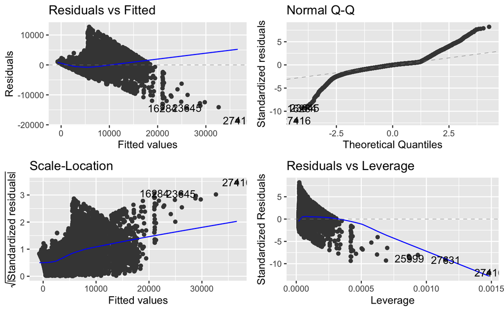

```r
library(ggfortify)
autoplot(model)
```

*** 5. Shortly we may try a regression fit using one or more of the categorical predictors cut, clarity and color, so let’s investigate these predictors:

*** i. Investigate the factor levels of these predictors. How many dummy variables do you expect for each of them?

```r
unique(diamonds_no_xyz$cut)
```

```
[1] "Ideal"     "Premium"   "Good"      "Very Good" "Fair"
```

cut <- 4 clarity <- 7 color <- 6

*** ii. Use the dummy_cols() function in the fastDummies package to generate dummies for these predictors and check the number of dummies in each case.

```r
library(fastDummies)

dummy_cut <- diamonds_no_xyz %>%
  dummy_cols(select_columns = c("cut", "clarity", "color"), remove_first_dummy = TRUE, remove_selected_columns = TRUE)

dummy_cut
```

| X1 | carat | depth | table | price | cut_Good | cut_Ideal | cut_Premium | cut_Very Good | clarity_IF | clarity_SI1 | clarity_SI2 | clarity_VS1 | clarity_VS2 | clarity_VVS1 | clarity_VVS2 | color_E | color_F | color_G | color_H | color_I | color_J |
| --- | --- | --- | --- | --- | --- | --- | --- | --- | --- | --- | --- | --- | --- | --- | --- | --- | --- | --- | --- | --- | --- |
| 1 | 0.23 | 61.5 | 55.0 | 326 | 0 | 1 | 0 | 0 | 0 | 0 | 1 | 0 | 0 | 0 | 0 | 1 | 0 | 0 | 0 | 0 | 0 |
| 2 | 0.21 | 59.8 | 61.0 | 326 | 0 | 0 | 1 | 0 | 0 | 1 | 0 | 0 | 0 | 0 | 0 | 1 | 0 | 0 | 0 | 0 | 0 |
| 3 | 0.23 | 56.9 | 65.0 | 327 | 1 | 0 | 0 | 0 | 0 | 0 | 0 | 1 | 0 | 0 | 0 | 1 | 0 | 0 | 0 | 0 | 0 |
| 4 | 0.29 | 62.4 | 58.0 | 334 | 0 | 0 | 1 | 0 | 0 | 0 | 0 | 0 | 1 | 0 | 0 | 0 | 0 | 0 | 0 | 1 | 0 |
| 5 | 0.31 | 63.3 | 58.0 | 335 | 1 | 0 | 0 | 0 | 0 | 0 | 1 | 0 | 0 | 0 | 0 | 0 | 0 | 0 | 0 | 0 | 1 |
| 6 | 0.24 | 62.8 | 57.0 | 336 | 0 | 0 | 0 | 1 | 0 | 0 | 0 | 0 | 0 | 0 | 1 | 0 | 0 | 0 | 0 | 0 | 1 |
| 7 | 0.24 | 62.3 | 57.0 | 336 | 0 | 0 | 0 | 1 | 0 | 0 | 0 | 0 | 0 | 1 | 0 | 0 | 0 | 0 | 0 | 1 | 0 |
| 8 | 0.26 | 61.9 | 55.0 | 337 | 0 | 0 | 0 | 1 | 0 | 1 | 0 | 0 | 0 | 0 | 0 | 0 | 0 | 0 | 1 | 0 | 0 |
| 9 | 0.22 | 65.1 | 61.0 | 337 | 0 | 0 | 0 | 0 | 0 | 0 | 0 | 0 | 1 | 0 | 0 | 1 | 0 | 0 | 0 | 0 | 0 |
| 10 | 0.23 | 59.4 | 61.0 | 338 | 0 | 0 | 0 | 1 | 0 | 0 | 0 | 1 | 0 | 0 | 0 | 0 | 0 | 0 | 1 | 0 | 0 |

[output cut: 990 more lines]

*** 6. Going forward we’ll let R handle dummy variable creation for categorical predictors in regression fitting (remember lm() will generate the correct numbers of dummy levels automatically, absorbing one of the levels into the intercept as a reference level)

*** i. First, we’ll start with simple linear regression. Regress price on carat and check the regression diagnostics.

*** ii. Run a regression with one or both of the predictor and response variables log() transformed and recheck the diagnostics. Do you see any improvement?

*** iii. Let’s use log() transformations of both predictor and response. Next, experiment with adding a single categorical predictor into the model. Which categorical predictor is best? [Hint - investigate r2 values]